# A3. Modelos ARIMA: Tipo de cambio USD/MXN y Cierre Mensual Máximo de NU

Lucy Janell Quero Pablo

2025-03-05

# Librerias utilizadas

```r
library(magick)
library(dynlm)
library(orcutt)
library(nlWaldTest)
library(zoo)
library(pdfetch)
library(lmtest)
library(broom)
library(car)
library(sandwich)
library(knitr)
library(forecast)
library(readxl)
library(tseries)
library(dplyr)
library(lubridate)  # Para trabajar con fechas
library(quantmod)
library(writexl)
```

# Enfoque

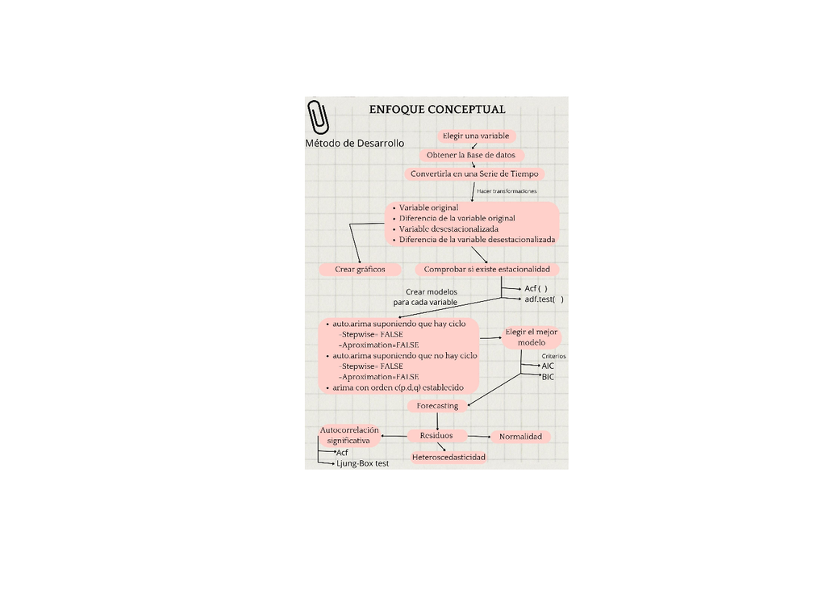

```r
mi_imagen <- image_read("C:/Users/LucyI/Downloads/Econometria 2/enfoque.jpg")
# Mostrar la imagen
plot(mi_imagen)
```

# Conceptos

## Estacionariedad

Una serie de tiempo es estacionaria cuando sus propiedades estadísticas (media, varianza y autocorrelación) permanecen constantes a lo largo del tiempo. En otras palabras, no presenta tendencias, estacionalidad u otros patrones sistemáticos que cambian con el tiempo. Los modelos ARIMA asumen que la serie de tiempo es estacionaria. Si la serie no es estacionaria, las predicciones del modelo pueden ser poco confiables. Por lo tanto, un paso crucial antes de aplicar un modelo ARIMA es verificar y, si es necesario, transformar la serie para que sea estacionaria. En un modelo ARIMA, el componente “I” (Integrated) se refiere al proceso de diferenciación, que se utiliza para hacer que una serie no estacionaria sea estacionaria.

### Función acf ( ) :

La función calcula y gráfica la función de autocorrelación (ACF) de una serie de tiempo. El ACF mide la evaluación entre los valores de la serie en diferentes rezagos (intervalos de tiempo). En una serie estacionaria, el ACF tiende a disminuir rápidamente a medida que aumenta el rezago. Si la ACF disminuye lentamente o muestra patrones significativos en rezagos largos, esto sugiere que la serie no es estacionaria.

### Función adf.test( ):

La prueba de Dickey-Fuller es una prueba estadística formal para determinar si una serie de tiempo tiene una raíz unitaria, que es un indicador de no estacionariedad. Hipótesis nula (H0) : La serie de tiempo tiene una raíz unitaria (no es estacionaria). Hipótesis alternativa (H1) : La serie de tiempo no tiene una raíz unitaria (es estacionaria).

## Estacionalidad

La estacionalidad se refiere a un patrón repetitivo y predecible en una serie de tiempo que ocurre a intervalos regulares. Estos intervalos pueden ser diarios, semanales o cualquier otro período fijo. Los modelos ARIMA clásicos están diseñados para modelar series de tiempo estacionarias. Sin embargo, muchas series de tiempo del mundo real exhiben estacionalidad, lo que las hace no estacionarias. Para abordar esto, se ha desarrollado una extensión de los modelos ARIMA llamada ARIMA estacional (SARIMA).

## Criterios de Información

### Criterio de Información de Akaike (AIC):

El AIC es una medida que evalúa la calidad de un modelo estadístico, teniendo en cuenta tanto su ajuste a los datos como su complejidad. En esencia, busca encontrar el equilibrio óptimo entre la bondad de ajuste y el número de parámetros utilizados en el modelo. Un valor de AIC más bajo indica un mejor modelo, ya que sugiere que el modelo logra un buen ajuste con la menor complejidad posible. Es importante destacar que el AIC es especialmente útil para comparar modelos que no están anidados, es decir, modelos que no son subconjuntos uno del otro.

### Criterio de Información Bayesiano (BIC):

El BIC, similar al AIC, es un criterio para la selección de modelos que considera tanto el ajuste a los datos como la complejidad del modelo. Sin embargo, el BIC tiende a penalizar más fuertemente la complejidad del modelo en comparación con el AIC, especialmente cuando el tamaño de la muestra es grande. Por lo tanto, el BIC favorece modelos más simples. Al igual que con el AIC, un valor de BIC más bajo indica un mejor modelo. El BIC es particularmente útil cuando se busca identificar el modelo más parsimonioso, es decir, el modelo más simple que aún proporciona un buen ajuste a los datos.

## Residuos

Representan la diferencia entre los valores observados en un conjunto de datos y los valores predichos por un modelo. Un análisis exhaustivo de los residuos es fundamental para evaluar la calidad y validez de un modelo. Si el modelo se ajusta bien a los datos, los residuos deberían comportarse de manera aleatoria, sin patrones discernibles.

### Autocorrelación Significativa:

Uno de los aspectos críticos a evaluar en los residuos es la autocorrelación significativa. Esto ocurre cuando los residuos en diferentes puntos del tiempo están correlacionados entre sí, lo que indica que el modelo no ha capturado completamente los patrones en los datos. Para detectar la autocorrelación, se utilizan herramientas como el Acf (Función de Autocorrelación) y la prueba de Ljung-Box. Si se encuentra autocorrelación significativa, sugiere que el modelo puede necesitar ajustes adicionales para mejorar su capacidad predictiva.

### Normalidad:

Los residuos deben seguir una distribución normal, lo que indica que los errores del modelo son aleatorios y no sesgados. Si los residuos no son normales, esto puede afectar la validez de las inferencias estadísticas realizadas con el modelo.

### Heteroscedasticidad:

La heteroscedasticidad se refiere a la situación en la que la varianza de los residuos no es constante a lo largo del rango de valores predichos. En otras palabras, la dispersión de los errores varía. La presencia de heteroscedasticidad puede invalidar las pruebas de significancia y afectar la precisión de las predicciones del modelo.

# Tipo de cambio FIX (USD-PESO MEX)

El tipo de cambio (FIX) es determinado por el Banco de México con base en un promedio de cotizaciones del mercado de cambios al mayoreo para operaciones liquidables el segundo día hábil bancario siguiente y que son obtenidas de plataformas de transacción cambiaria y otros medios electrónicos con representatividad en el mercado de cambios. El Banco de México da a conocer el FIX a partir de las 12:00 horas de todos los días hábiles bancarios, se publica en el Diario Oficial de la Federación (DOF) un día hábil bancario después de la fecha de determinación y es utilizado para solventar obligaciones denominadas en dólares liquidables en la República Mexicana al día siguiente de la publicación en el DOF. Para mayor información sobre este tipo de cambio consulte: El Título Tercero, Capítulo V de la Circular 3/2012 del Banco de México.

## Justificación

En un inicio pensé que tipo de cambio USD/MXN es una variable ideal para modelar con ARIMA debido a su naturaleza intrínsecamente temporal y su volatilidad, características que se alinean perfectamente con los supuestos y capacidades de este modelo además de que no es una variable acumulativa. En el contexto del análisis de series temporales, el tipo de cambio representa una secuencia de datos ordenados cronológicamente, donde las fluctuaciones revelan patrones y dependencias a lo largo del tiempo. La relevancia de modelar el tipo de cambio USD/MXN se amplifica por su importa en la economía mexicana, donde las variaciones en esta tasa afectan directamente el comercio internacional, la inflación, las inversiones y las decisiones financieras tanto del sector público como privado. Al pronosticar con precisión las tendencias del tipo de cambio, las empresas pueden optimizar sus estrategias de cobertura cambiaria, los inversores pueden tomar decisiones informadas sobre activos denominados en pesos mexicanos y los responsables de la política económica pueden anticipar y mitigar los impactos de la volatilidad cambiaria.

```r
BD_1 <- read_xlsx("C:/Users/LucyI/Downloads/Econometria 2/BD_1.xlsx")
#View(BD_1)
```

Los datos fueron tomados de Banco de México Portal del mercado cambiario

## Arreglo de datos faltantes y convertir en serie de tiempo

La BD se convirtió a clase data frame y se cambiaron los datos faltantes por “NA” de tipo numérico para que se puedan identificar y sustituir por datos de una interpolación lineal. Podemos ver que no todas las bases de datos ya están trabajadas a nuestra disposición. Incluso a veces recopilar la base de datos puede ser la parte más complicada para crear un modelo.

```r
df <- data.frame(BD_1)
df <- df %>%
  mutate(Fecha = dmy(Fecha))

df$FIX[df$FIX == "N/E"] <- NA
df$FIX <- as.numeric(df$FIX)

ts_fix <- ts(df$FIX, frequency = 365.25, start = c(1991, as.numeric(format(min(df$Fecha, na.rm = TRUE), "%j"))))
ts_fix_interp <- na.interp(ts_fix) # Interpolación lineal

ultima_fecha <- max(df$Fecha, na.rm = TRUE)
fecha_final <- as.Date("2025-03-04")
dias_adicionales <- as.numeric(fecha_final - ultima_fecha)

#ts de la variable
Usd1 <- ts(c(ts_fix_interp, rep(NA, dias_adicionales)),
                       frequency = 365.25,
                       start = c(1991, as.numeric(format(min(df$Fecha, na.rm = TRUE), "%j"))))
```

## Transformaciones de la variable

Nota: decidí trabajar con todas las transformaciones desde un inicio no solo para optimizar el código sino para también evitar que se me escape algún modelo. Al final vuelvo a comprobar que la variable optima sí sea estacionaria.

```r
DUsd1<- diff(Usd1) #Diferencias de la variable original
descomposicion1<-decompose(Usd1)
UsdDes1<-Usd1-descomposicion1$seasonal #Variable desestacionalizada
DUsdDes1<-diff(UsdDes1)# Diferencias de la variable desestacionalizada
```

## Graficos

### Descomposición

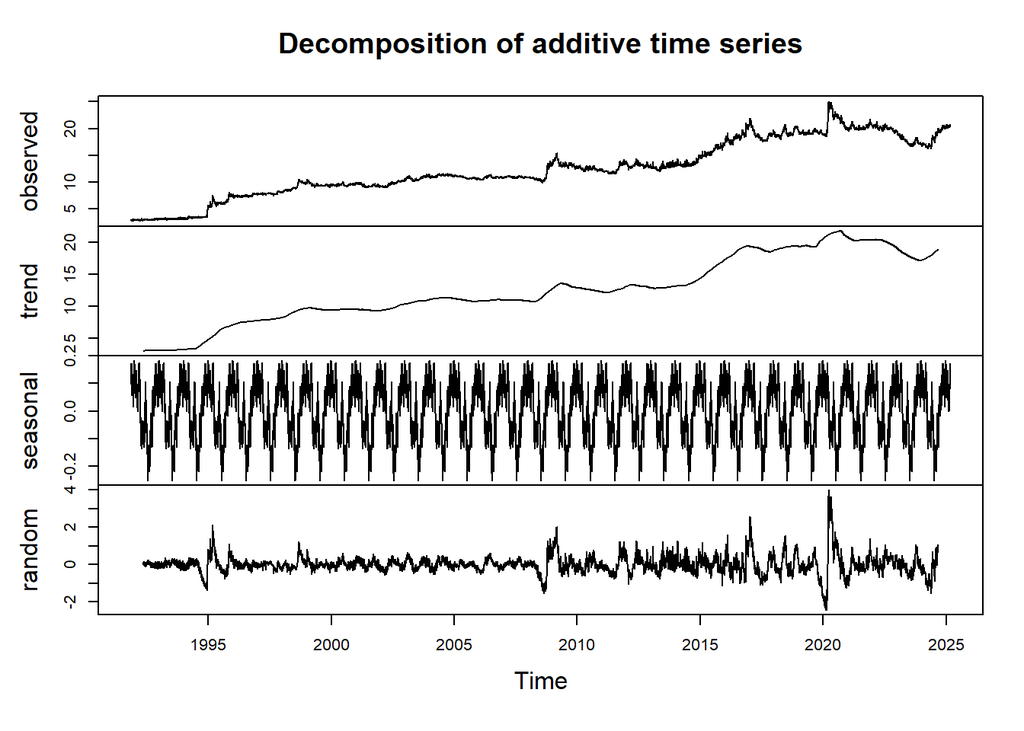

```r
plot(descomposicion1)
```

*El componente aleatorio o residual muestra fluctuaciones irregulares que no se explican por la tendencia o la estacionalidad. Se observa un aumento de la variabilidad en los últimos años, lo que podría indicar eventos inesperados o un mayor nivel de ruido.

### Serie de Tiempo

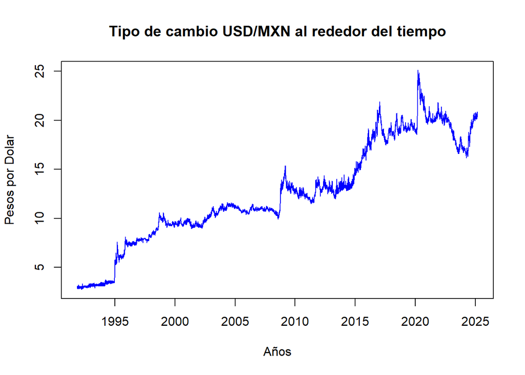

```r
plot(Usd1, main="Tipo de cambio USD/MXN al rededor del tiempo",ylab="Pesos por Dolar",xlab="Años",col="blue")
```

En la evolución del tipo de cambio peso-dólar se observa una tendencia general de depreciación del peso mexicano frente al dólar a lo largo del tiempo. Varios eventos históricos han influido en esta tendencia. La crisis económica mexicana de 1994-1995, conocida como el “Efecto Tequila”, provocó una fuerte devaluación del peso. La crisis financiera mundial de 2008 también tuvo un impacto significativo en el tipo de cambio, al igual que la incertidumbre generada por la elección de Donald Trump como presidente de Estados Unidos en 2016 y la reciente pandemia de COVID-19. La depreciación del peso encarece las importaciones y puede generar inflación, pero también beneficia a las exportaciones mexicanas. Vemos que esta variable no tiene media constante y por tanto tampoco tiene reversión a la media, además, la varianza parece no ser demasiado volátil. Desde este punto podemos saber no es estacionaria.

### Diferencias de la Serie de Tipo

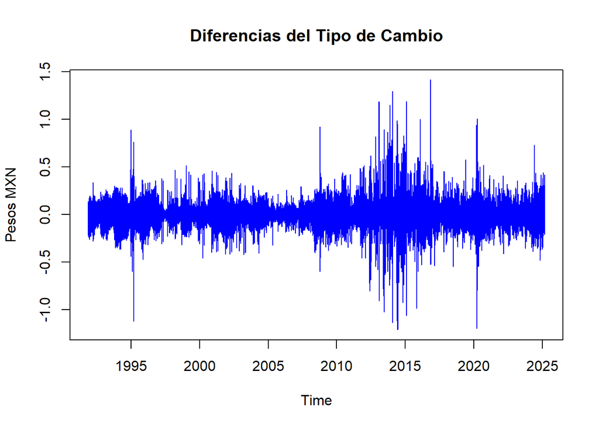

```r
plot(DUsd1,main="Diferencias del Tipo de Cambio",ylab="Pesos MXN",col="blue")
```

Cumple con una media constante igual a 0 y reversión a la media pero con alta volatilidad.

### Serie Desestacionalizada

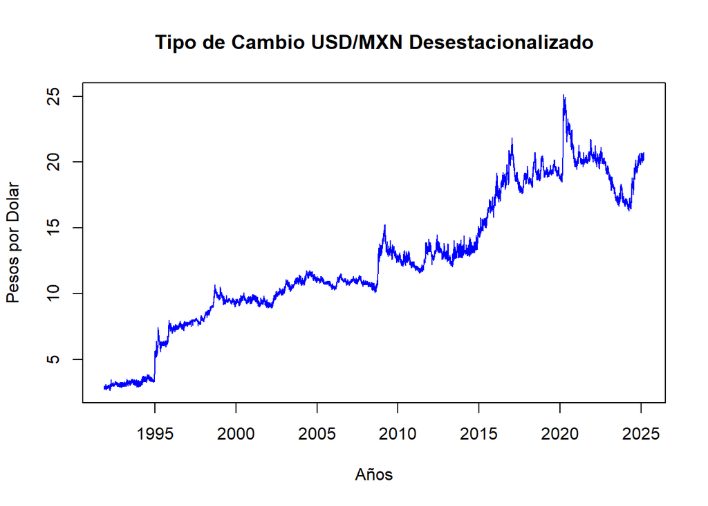

```r
plot(UsdDes1, main="Tipo de Cambio USD/MXN Desestacionalizado",ylab="Pesos por Dolar",xlab="Años",col="blue")
```

La grafica no cambia mucho al extraer el componente estacional

### Diferencias de la Serie Desestacionalizada

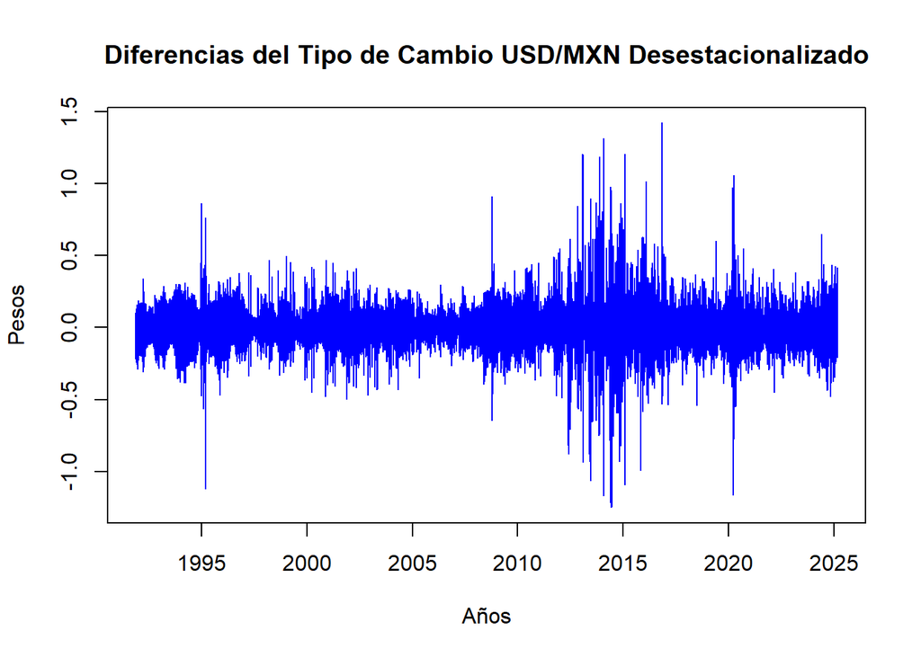

```r
plot(DUsdDes1, main="Diferencias del Tipo de Cambio USD/MXN Desestacionalizado",ylab="Pesos",xlab="Años",col="blue")
```

Ahora ya existe una media constante y reversión a la media pero con alta volatilidad.

## ACF´s

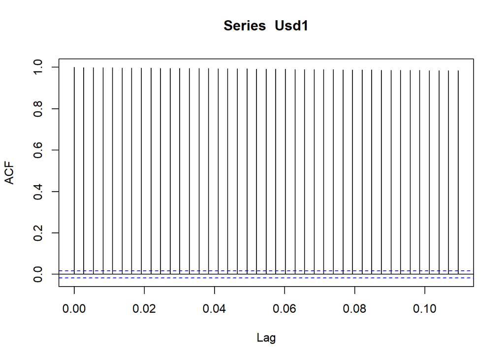

```r
acf(Usd1)
```

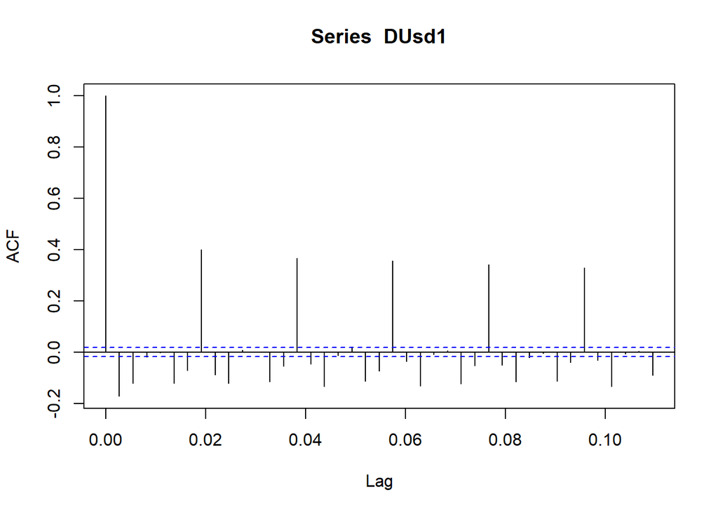

```r
acf(DUsd1)
```

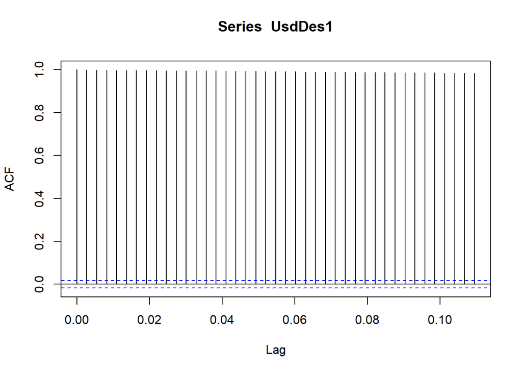

```r
acf(UsdDes1)
```

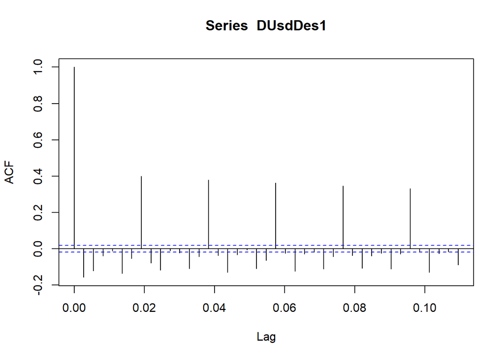

```r
acf(DUsdDes1)
```

Aunque aplicar diferenciación ayuda, sigue existiendo un componente cíclico donde los rezagos son significativos por lo que es muy probable que las variables no sean estacionarias. Además, estos acf no nos sirven para establecer el orden p en el ARIMA

## Dickey Fuller

```r
adf.test(Usd1)
```

```
##
##  Augmented Dickey-Fuller Test
##
## data:  Usd1
## Dickey-Fuller = -3.5314, Lag order = 22, p-value = 0.03913
## alternative hypothesis: stationary
```

```r
adf.test(DUsd1)
```

```
##
##  Augmented Dickey-Fuller Test
##
## data:  DUsd1
## Dickey-Fuller = -21.724, Lag order = 22, p-value = 0.01
## alternative hypothesis: stationary
```

```r
adf.test(UsdDes1)
```

```
##
##  Augmented Dickey-Fuller Test
##
## data:  UsdDes1
## Dickey-Fuller = -3.4655, Lag order = 22, p-value = 0.04549
## alternative hypothesis: stationary
```

```r
adf.test(DUsdDes1)
```

```
##
##  Augmented Dickey-Fuller Test
##
## data:  DUsdDes1
## Dickey-Fuller = -21.915, Lag order = 22, p-value = 0.01
## alternative hypothesis: stationary
```

Se vuelven estacionarias hasta los 22 rezagos que ya es demasiado. En este punto ya no es conveniente aplicar modelos. Se podría hacer varias diferenciaciones pero obligar a la variable a ser estacionaria de ese modo no es conveniente porque al final seria complicado interpretar los resultados.

## Exportar una segunda BD

Una alternativa es recortar la serie. La base ahora es a partir del 2023 al 4 de marzo del presente año. Se decidió el corte de este modo porque así se tienen dos años completos para que el modelo pueda detectar si existen patrones estacionales.

```r
BD_2 <- read_xlsx("C:/Users/LucyI/Downloads/Econometria 2/BD_2.xlsx")
```

## Arreglo de datos faltantes y convertir en serie de tiempo

Se realiza el mismo procedimiento que antes

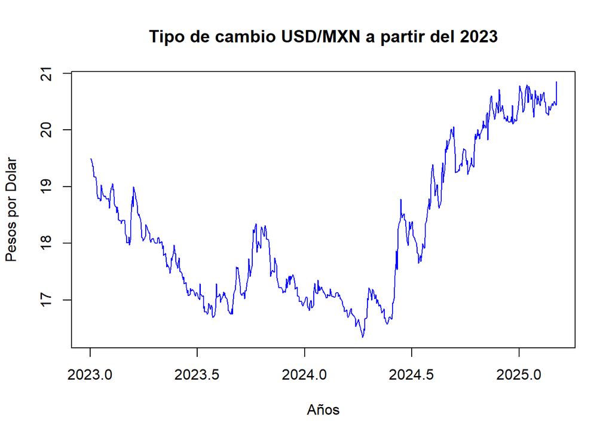

```r
df2 <- data.frame(BD_2)
df2 <- df2 %>%
  mutate(Fecha = dmy(Fecha))

df2$FIX[df2$FIX == "N/E"] <- NA
df2$FIX <- as.numeric(df2$FIX)

ts_fix2 <- ts(df2$FIX, frequency = 365.25, start = c(1991, as.numeric(format(min(df2$Fecha, na.rm = TRUE), "%j"))))

ts_fix_interp2 <- na.interp(ts_fix2) # Interpolación lineal

ultima_fecha2 <- max(df2$Fecha, na.rm = TRUE)
fecha_final2 <- as.Date("2025-03-04")
dias_adicionales2 <- as.numeric(fecha_final2 - ultima_fecha2)

Usd2 <- ts(c(ts_fix_interp2, rep(NA, dias_adicionales2)),
                       frequency = 365.25,
                       start = c(2023, as.numeric(format(min(df2$Fecha, na.rm = TRUE), "%j"))))

plot(Usd2, main="Tipo de cambio USD/MXN a partir del 2023",ylab="Pesos por Dolar",xlab="Años",col="blue")
```

La interpretación es la misma.

## Transformaciones de la variable

```r
DUsd2<- diff(Usd2) #Diferencias de la variable original
descomposicion2<-decompose(Usd2)
UsdDes2<-Usd2-descomposicion2$seasonal #Variable desestacionalizada
DUsdDes2<-diff(UsdDes2)
```

## ACF

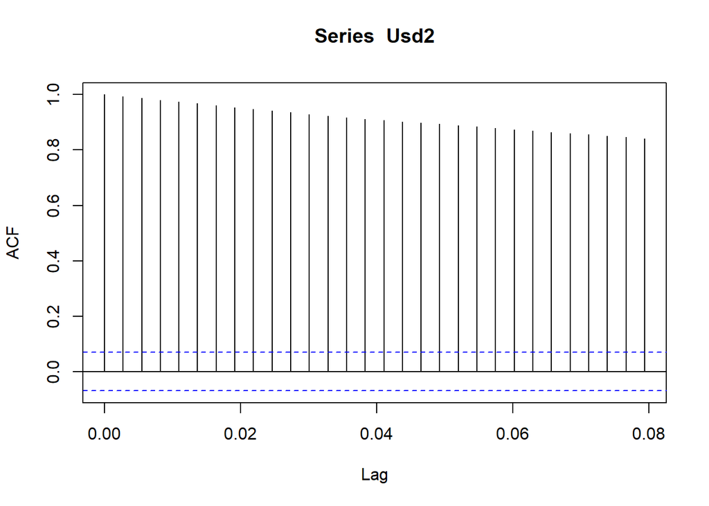

```r
acf(Usd2)
```

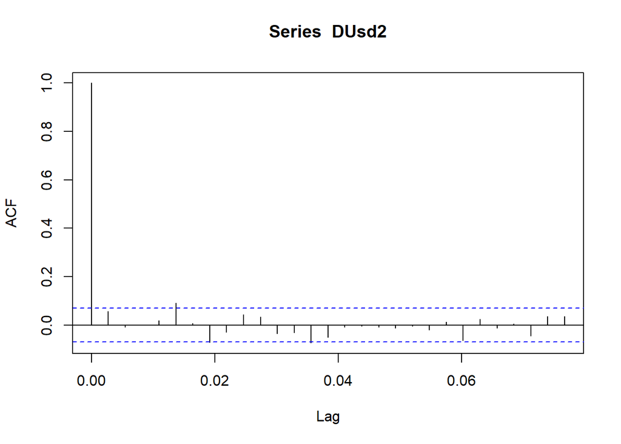

```r
acf(DUsd2)
```

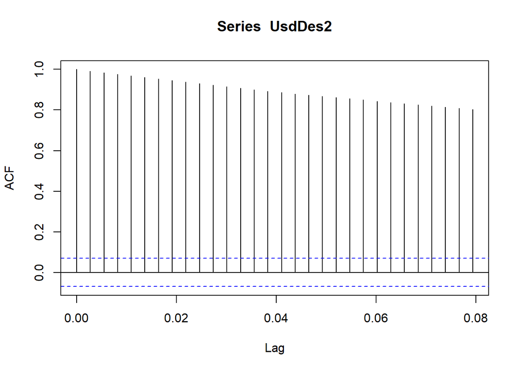

```r
acf(UsdDes2)
```

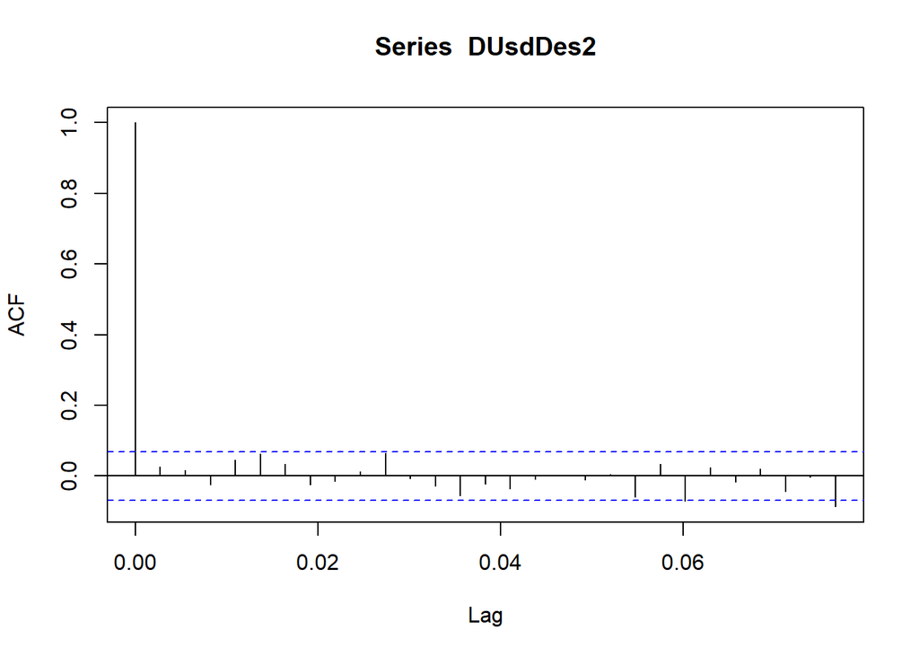

```r
acf(DUsdDes2)
```

Probablemente ahora las variables diferenciadas sean estacionarias

## Dickey Fuller

```r
adf.test(Usd2)
```

```
##
##  Augmented Dickey-Fuller Test
##
## data:  Usd2
## Dickey-Fuller = -1.9648, Lag order = 9, p-value = 0.5932
## alternative hypothesis: stationary
```

```r
adf.test(DUsd2)
```

```
##
##  Augmented Dickey-Fuller Test
##
## data:  DUsd2
## Dickey-Fuller = -8.5447, Lag order = 9, p-value = 0.01
## alternative hypothesis: stationary
```

```r
adf.test(UsdDes2)
```

```
##
##  Augmented Dickey-Fuller Test
##
## data:  UsdDes2
## Dickey-Fuller = -1.6451, Lag order = 9, p-value = 0.7285
## alternative hypothesis: stationary
```

```r
adf.test(DUsdDes2)
```

```
##
##  Augmented Dickey-Fuller Test
##
## data:  DUsdDes2
## Dickey-Fuller = -8.0551, Lag order = 9, p-value = 0.01
## alternative hypothesis: stationary
```

Solo las variables diferenciadas son estacionarias, supuestamente hasta los 9 rezagos, veamos si son estacionarias antes ya que los acf lo sugieren.

```r
adf.test(DUsd2,k=1)
```

```
##
##  Augmented Dickey-Fuller Test
##
## data:  DUsd2
## Dickey-Fuller = -19.503, Lag order = 1, p-value = 0.01
## alternative hypothesis: stationary
```

```r
adf.test(DUsd2,k=2)
```

```
##
##  Augmented Dickey-Fuller Test
##
## data:  DUsd2
## Dickey-Fuller = -16.053, Lag order = 2, p-value = 0.01
## alternative hypothesis: stationary
```

```r
adf.test(DUsd2,k=3)
```

```
##
##  Augmented Dickey-Fuller Test
##
## data:  DUsd2
## Dickey-Fuller = -13.711, Lag order = 3, p-value = 0.01
## alternative hypothesis: stationary
```

```r
adf.test(DUsd2,k=4)
```

```
##
##  Augmented Dickey-Fuller Test
##
## data:  DUsd2
## Dickey-Fuller = -11.263, Lag order = 4, p-value = 0.01
## alternative hypothesis: stationary
```

```r
adf.test(DUsd2,k=5)
```

```
##
##  Augmented Dickey-Fuller Test
##
## data:  DUsd2
## Dickey-Fuller = -10.537, Lag order = 5, p-value = 0.01
## alternative hypothesis: stationary
```

```r
adf.test(DUsd2,k=6)
```

```
##
##  Augmented Dickey-Fuller Test
##
## data:  DUsd2
## Dickey-Fuller = -10.607, Lag order = 6, p-value = 0.01
## alternative hypothesis: stationary
```

```r
adf.test(DUsd2,k=7)
```

```
##
##  Augmented Dickey-Fuller Test
##
## data:  DUsd2
## Dickey-Fuller = -10.166, Lag order = 7, p-value = 0.01
## alternative hypothesis: stationary
```

```r
adf.test(DUsd2,k=8)
```

```
##
##  Augmented Dickey-Fuller Test
##
## data:  DUsd2
## Dickey-Fuller = -9.156, Lag order = 8, p-value = 0.01
## alternative hypothesis: stationary
```

```r
adf.test(DUsdDes2,k=1)
```

```
##
##  Augmented Dickey-Fuller Test
##
## data:  DUsdDes2
## Dickey-Fuller = -19.267, Lag order = 1, p-value = 0.01
## alternative hypothesis: stationary
```

```r
adf.test(DUsdDes2,k=2)
```

```
##
##  Augmented Dickey-Fuller Test
##
## data:  DUsdDes2
## Dickey-Fuller = -16.354, Lag order = 2, p-value = 0.01
## alternative hypothesis: stationary
```

```r
adf.test(DUsdDes2,k=3)
```

```
##
##  Augmented Dickey-Fuller Test
##
## data:  DUsdDes2
## Dickey-Fuller = -13.512, Lag order = 3, p-value = 0.01
## alternative hypothesis: stationary
```

```r
adf.test(DUsdDes2,k=4)
```

```
##
##  Augmented Dickey-Fuller Test
##
## data:  DUsdDes2
## Dickey-Fuller = -11.435, Lag order = 4, p-value = 0.01
## alternative hypothesis: stationary
```

```r
adf.test(DUsdDes2,k=5)
```

```
##
##  Augmented Dickey-Fuller Test
##
## data:  DUsdDes2
## Dickey-Fuller = -10.314, Lag order = 5, p-value = 0.01
## alternative hypothesis: stationary
```

```r
adf.test(DUsdDes2,k=6)
```

```
##
##  Augmented Dickey-Fuller Test
##
## data:  DUsdDes2
## Dickey-Fuller = -9.959, Lag order = 6, p-value = 0.01
## alternative hypothesis: stationary
```

```r
adf.test(DUsdDes2,k=7)
```

```
##
##  Augmented Dickey-Fuller Test
##
## data:  DUsdDes2
## Dickey-Fuller = -9.5226, Lag order = 7, p-value = 0.01
## alternative hypothesis: stationary
```

```r
adf.test(DUsdDes2,k=8)
```

```
##
##  Augmented Dickey-Fuller Test
##
## data:  DUsdDes2
## Dickey-Fuller = -8.9362, Lag order = 8, p-value = 0.01
## alternative hypothesis: stationary
```

Las variables diferenciadas si son estacionarias por lo que podemos aplicar modelos.

## Modelos

Realizamos todos los modelos que aprendimos en clase, quizas algunos no sean validos pero solo necesitamos que el mejor lo sea.

```r
#autoarima asumiendo que no hay ciclo
m1<- auto.arima(Usd2, seasonal= FALSE)# Asumo que no hay ciclo
m2<- auto.arima(DUsd2, seasonal= FALSE)
m3<- auto.arima(UsdDes2,seasonal= FALSE)
m4<- auto.arima(DUsdDes2, seasonal= FALSE)


## Stepwise y aproximation false
m5<-auto.arima(Usd2,seasonal = FALSE,
                 stepwise = FALSE,approximation = FALSE)
m6<-auto.arima(DUsd2,seasonal = FALSE,
                 stepwise = FALSE,approximation = FALSE)
m7<-auto.arima(UsdDes2,seasonal = FALSE,
                 stepwise = FALSE,approximation = FALSE)
m8<-auto.arima(DUsdDes2,seasonal = FALSE,
                 stepwise = FALSE,approximation = FALSE)

#autoarima asumiendo que hay ciclo
m9<- auto.arima(Usd2, seasonal= TRUE)# Asumo que no hay ciclo
m10<- auto.arima(DUsd2, seasonal= TRUE)
m11<- auto.arima(UsdDes2,seasonal= TRUE)
m12<- auto.arima(DUsdDes2, seasonal= TRUE)

## Stepwise y aproximation false
m13<-auto.arima(Usd2,seasonal = TRUE,
                 stepwise = FALSE,approximation = FALSE)
m14<-auto.arima(DUsd2,seasonal = TRUE,
                 stepwise = FALSE,approximation = FALSE)
m15<-auto.arima(UsdDes2,seasonal = TRUE,
                 stepwise = FALSE,approximation = FALSE)
m16<-auto.arima(DUsdDes2,seasonal = TRUE,
                 stepwise = FALSE,approximation = FALSE)
#Con tendencia
trend<-seq_along(Usd2)
m17<-auto.arima(Usd2,d=1,xreg=trend)
m18<-auto.arima(Usd2,d=0,xreg=trend)
```

## Comparación de Criterios de Información

```r
AIC_BIC <- data.frame(
  Modelo = c("m1", "m2", "m3","m4","m5","m6","m7","m8","m9","m10","m11", "m12", "m13","m14","m15","m16","m17","m18"),
  AIC = c(m1$aic,m2$aic,m3$aic,m4$aic,m5$aic,m6$aic,m7$aic,m8$aic,m9$aic,m10$aic,m11$aic,m12$aic,m13$aic,m14$aic,m15$aic,m16$aic,m17$aic,m18$aic),
  BIC = c(m1$bic,m2$bic,m3$bic,m4$bic,m5$bic,m6$bic,m7$bic,m8$bic,m9$bic,m10$bic,m11$bic,m12$bic,m13$bic,m14$bic,m15$bic,m16$bic,m17$bic,m18$bic)
)

# Mostrar la tabla
knitr::kable(AIC_BIC, caption = "Comparación de AIC y BIC de los modelos auto.arima")
```

Comparación de AIC y BIC de los modelos auto.arima

| Modelo | AIC | BIC |
| --- | --- | --- |
| m1 | -990.1929 | -980.8413 |
| m2 | -1193.0368 | -1160.3060 |
| m3 | -997.5821 | -988.2304 |
| m4 | -1196.7964 | -1164.0657 |
| m5 | -1195.0127 | -1166.9577 |
| m6 | -1195.0131 | -1166.9581 |
| m7 | -1198.7632 | -1170.7083 |
| m8 | -1198.7632 | -1170.7083 |
| m9 | -990.1929 | -980.8413 |
| m10 | -1193.0368 | -1160.3060 |
| m11 | -997.5821 | -988.2304 |
| m12 | -1196.7964 | -1164.0657 |
| m13 | -1195.0127 | -1166.9577 |
| m14 | -1195.0131 | -1166.9581 |
| m15 | -1198.7632 | -1170.7083 |
| m16 | -1198.7632 | -1170.7083 |
| m17 | -1298.0655 | -1288.7114 |
| m18 | -368.6825 | -331.2557 |

Ignoramos m17 ya que con el no se puede hacer forecasting debido a que necesita datos futuros de la tendencia (error: No regressors provided) Entonces m7, m8, m15 y m16 tienen los mejores criterios de información. Revisemos si son el mismo modelo

```r
m7
```

```
## Series: UsdDes2
## ARIMA(5,2,0)
##
## Coefficients:
##           ar1      ar2      ar3      ar4      ar5
##       -0.8389  -0.6790  -0.5605  -0.3695  -0.1657
## s.e.   0.0353   0.0444   0.0464   0.0444   0.0353
##
## sigma^2 = 0.01278:  log likelihood = 605.38
## AIC=-1198.76   AICc=-1198.66   BIC=-1170.71
```

```r
m8
```

```
## Series: DUsdDes2
## ARIMA(5,1,0)
##
## Coefficients:
##           ar1      ar2      ar3      ar4      ar5
##       -0.8389  -0.6790  -0.5605  -0.3695  -0.1657
## s.e.   0.0353   0.0444   0.0464   0.0444   0.0353
##
## sigma^2 = 0.01278:  log likelihood = 605.38
## AIC=-1198.76   AICc=-1198.66   BIC=-1170.71
```

```r
m15
```

```
## Series: UsdDes2
## ARIMA(5,2,0)
##
## Coefficients:
##           ar1      ar2      ar3      ar4      ar5
##       -0.8389  -0.6790  -0.5605  -0.3695  -0.1657
## s.e.   0.0353   0.0444   0.0464   0.0444   0.0353
##
## sigma^2 = 0.01278:  log likelihood = 605.38
## AIC=-1198.76   AICc=-1198.66   BIC=-1170.71
```

```r
m16
```

```
## Series: DUsdDes2
## ARIMA(5,1,0)
##
## Coefficients:
##           ar1      ar2      ar3      ar4      ar5
##       -0.8389  -0.6790  -0.5605  -0.3695  -0.1657
## s.e.   0.0353   0.0444   0.0464   0.0444   0.0353
##
## sigma^2 = 0.01278:  log likelihood = 605.38
## AIC=-1198.76   AICc=-1198.66   BIC=-1170.71
```

Efectivamente son el mismo modelo

## Mejor modelo

El mejor modelo es un ARIMA (5,2,0) La variable utilizada es la desestacionalizada con dos diferencias Veamos si es estacionaria

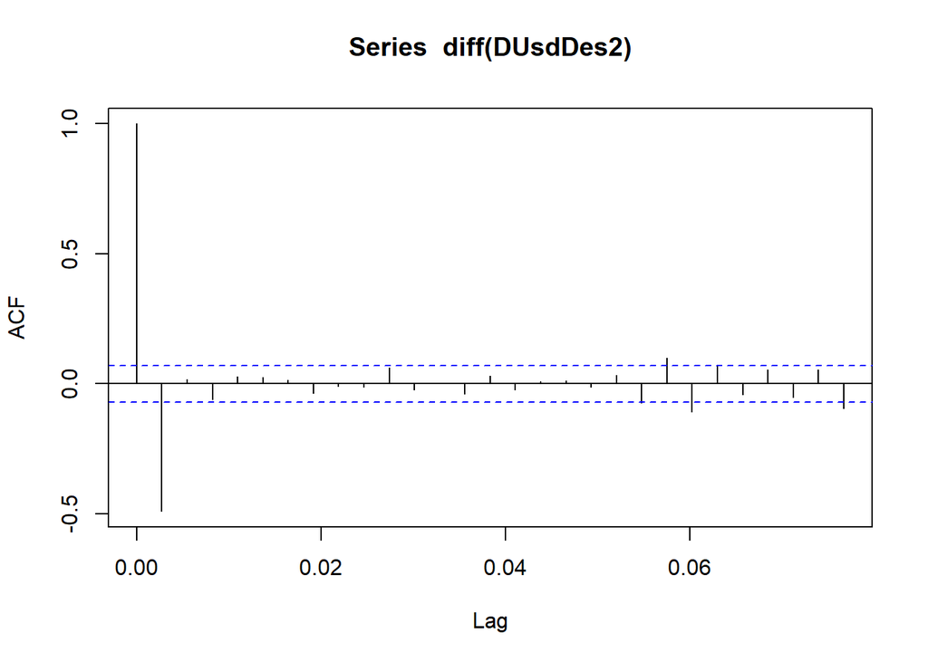

```r
acf(diff(DUsdDes2))
```

```r
adf.test(diff(DUsdDes2))
```

```
##
##  Augmented Dickey-Fuller Test
##
## data:  diff(DUsdDes2)
## Dickey-Fuller = -14.945, Lag order = 9, p-value = 0.01
## alternative hypothesis: stationary
```

Efectivamente pasa ambas pruebas por lo que es estacionario. Además el acf sugiere elegir solo un rezago, Veamos si es un mejor modelo

```r
macf<-Arima(UsdDes2,order = c(1,2,0))
macf
```

```
## Series: UsdDes2
## ARIMA(1,2,0)
##
## Coefficients:
##           ar1
##       -0.4948
## s.e.   0.0311
##
## sigma^2 = 0.01657:  log likelihood = 500.79
## AIC=-997.58   AICc=-997.57   BIC=-988.23
```

No es un mejor modelo ya que sus criterios de información son mas grandes.

## Prediccion

```r
forecast(m7,h=3)
```

```
##           Point Forecast    Lo 80    Hi 80    Lo 95    Hi 95
## 2025.1766       21.22147 21.07658 21.36636 20.99987 21.44306
## 2025.1793       21.32272 21.10070 21.54475 20.98316 21.66229
## 2025.1821       21.40788 21.11227 21.70349 20.95578 21.85998
```

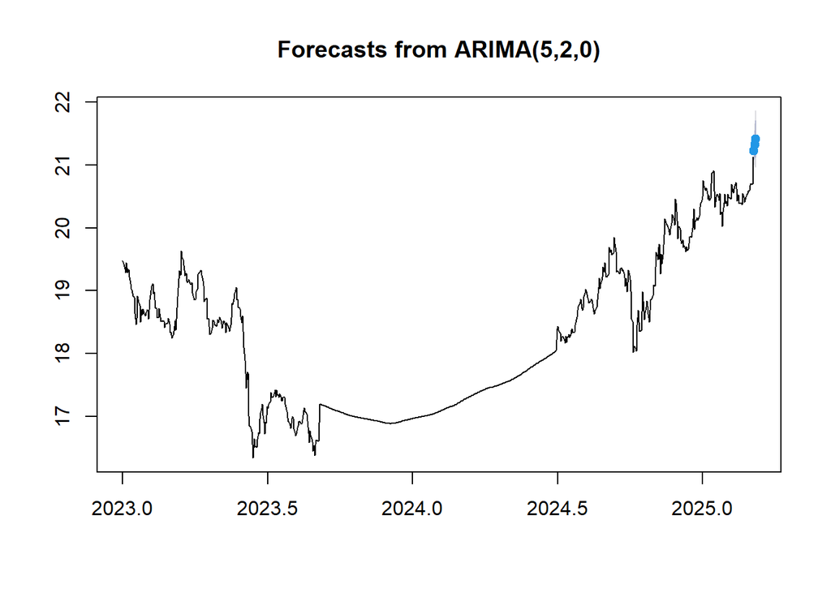

```r
plot(forecast::forecast(m7,h=3))
```

La grafica es diferente debido a que desestacionalizamos la variable, la predicción nos dice que el dólar subirá los siguientes tres días. Si comparamos el valor del 7 de marzo con el valor real tenemos 21.40788 vs 20.2830, existe un error de más de un peso. Parece ser un mal modelo

## Residuos

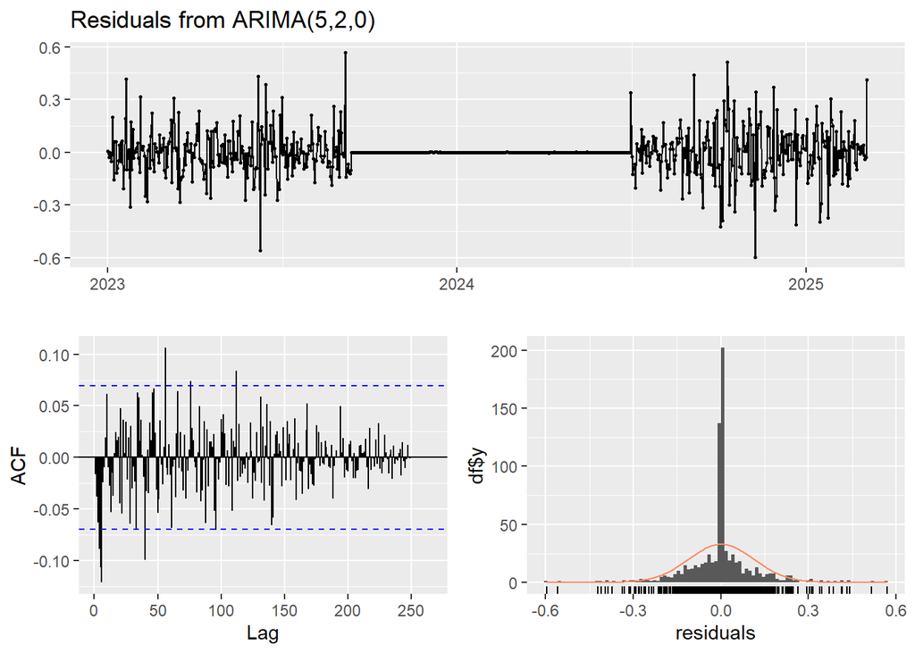

```
##
##  Ljung-Box test
##
## data:  Residuals from ARIMA(5,2,0)
## Q* = 191.61, df = 154, p-value = 0.02133
##
## Model df: 5.   Total lags used: 159
```

```r
checkresiduals(m7)
```

Esto es malo. La prueba L-Jung Box y el acf confirman la presencia de autocorrelación en los residuos, lo cual sugiere que el modelo ARIMA(5,2,0) no captura completamente los patrones de los datos de la serie temporal, esto desacredita al modelo y anula la confiabilidad. además los rezagos tienen un curtosis exagerada por lo que probablemente no sean normales.

## Conclusiones

A pesar de que se realizó la validación de los supuestos del modelo, el análisis de los residuos revela una insuficiencia en el ajuste del modelo a los datos. Esta discrepancia puede atribuirse, en parte, a las extensas transformaciones aplicadas a la variable para lograr la estacionariedad, así como a la considerable longitud de la serie temporal analizada.

Si bien otra reducción adicional de la serie temporal podría mejorar el ajuste del modelo, esta estrategia comprometería la representatividad de la serie, particularmente en lo que a mí respecta la idea de tener menos de dos años podría comprometer la identificación robusta de patrones de estacionalidad.

Por lo tanto, se concluye que el tipo de cambio USD/MXN, debido a su complejidad inherente, requiere un enfoque de modelado alternativo capaz de aprovechar la totalidad de la información contenida en la base de datos disponible. La incorporación de un conjunto de datos histórico más extenso resulta fundamental para optimizar el aprendizaje y la capacidad predictiva del modelo.

# Nu Holdings Ltd (Cierre Máximo por Mes)

Para subsanar las limitaciones observadas en el modelo anterior, se procedió al análisis de una variable alternativa: el precio de cierre máximo mensual de las acciones de Nu Holdings Ltd. (NU). La selección de este activo financiero respondió a un interés particular, derivado de su rendimiento favorable durante el desafío Actinver, donde me generó beneficios sustanciales.

Nu Holdings, una institución financiera digital brasileña, ha experimentado un crecimiento significativo en el mercado latinoamericano, impulsado por sus atractivas propuestas de ahorro. La predicción del precio de sus acciones reviste relevancia estratégica, ya que puede proporcionar información valiosa para la toma de decisiones de inversión.

## Obtener Datos

Se extrajeron los datos históricos del cierre por día a través de Yahoo!

```r
getSymbols("NU", from = "2021-12-09", to = Sys.Date(), src = "yahoo")
```

```
## [1] "NU"
```

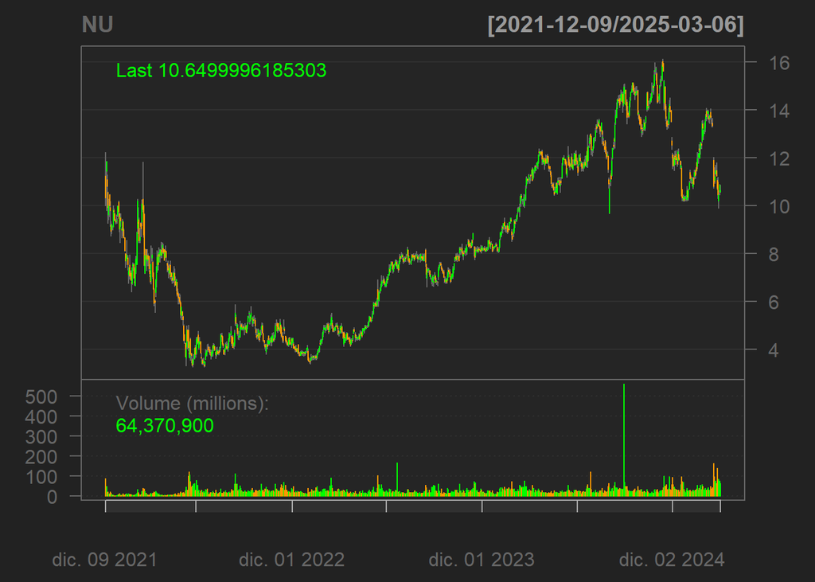

```r
BD_NU<-as.data.frame(NU)
BD_NU$Fecha <- rownames(BD_NU)
#Se exporta a excel para eliminar los datos inecesarios mas rapido, crear una tabla dinamica y extraer los cierres maximos por mes
#Exportar
#writexl::write_xlsx(BD_NU, "BD_NU.xlsx")

chartSeries(NU)
```

## Importar BD

Los datos diarios fueron manipulados en Excel para obtener solo el cierre máximo por mes

```r
NU<- read_excel("C:/Users/LucyI/Downloads/Econometria 2/BD_NU.xlsx",sheet = "Hoja1")
NU<-as.data.frame(NU)
NU.ts<-ts(NU$`Cierre Maximo`,
          frequency = 12,
          start = c(2021,12))
```

## Transformaciones de las variable

```r
DNu<-diff(NU.ts) #Diferencias de la variable original
descomposicion<-decompose(NU.ts)
NuDes<-NU.ts-descomposicion$seasonal #Variable desestacionalizada
DNuDes<-diff(NuDes)
```

## Grácficas

### Descomposición

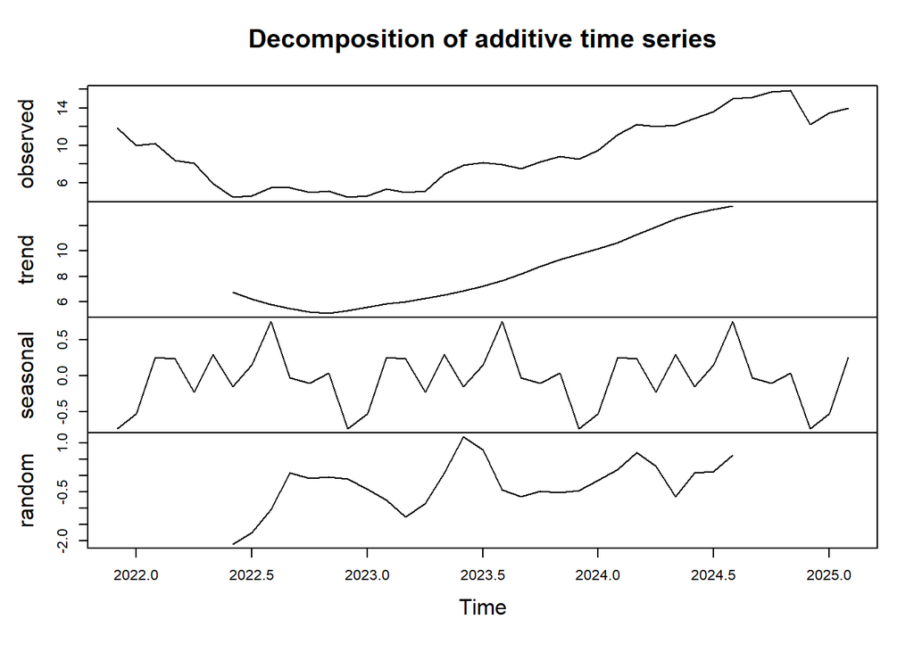

```r
plot(descomposicion)
```

- La tendencia representa el movimiento a largo plazo de los datos, excluyendo las fluctuaciones estacionales y aleatorias. Se observa que la tendencia es creciente, sobre todo a partir del año 2023.
- La estacionalidad representa patrones que se repiten a intervalos regulares, como variaciones diarias, semanales o anuales. Se puede observar que tiene una fluctuación constante durante todo el tiempo graficado, lo cual puede significar que la estacionalidad de los datos, tiene una fuerte presencia.
- El componente aleatorio o residual de la serie temporal. Representa las fluctuaciones que no se pueden explicar por la tendencia o la estacionalidad. Muestra el ruido o las irregularidades que quedan después de eliminar la tendencia y la estacionalidad.

### Cierre Máximo por mes

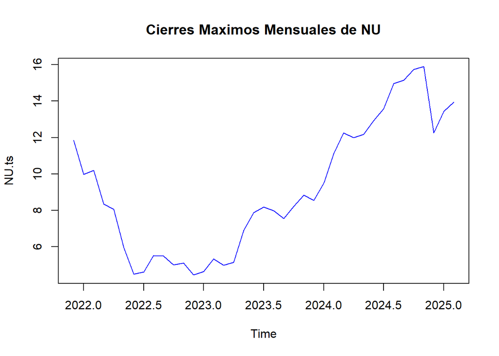

```r
plot(NU.ts,main="Cierres Maximos Mensuales de NU",col="blue")
```

Los cierres máximos mensuales no tienen una media constante ni reversión a la media además de que son volátiles. Podemos intuir que no son estacionarios

### Difencias

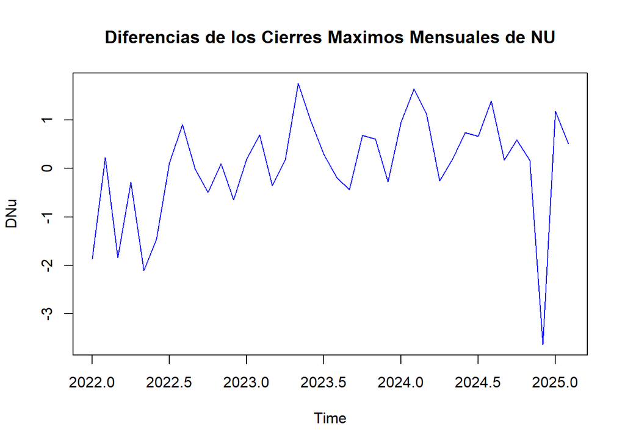

```r
plot(DNu,main="Diferencias de los Cierres Maximos Mensuales de NU",col="blue")
```

Las diferencias tienen alta volatilidad pero la media ya es más aproximada a cero y se puede considerar que existe reversión a la media porque periodos altos siguen de periodos bajos

### Desestacionalización

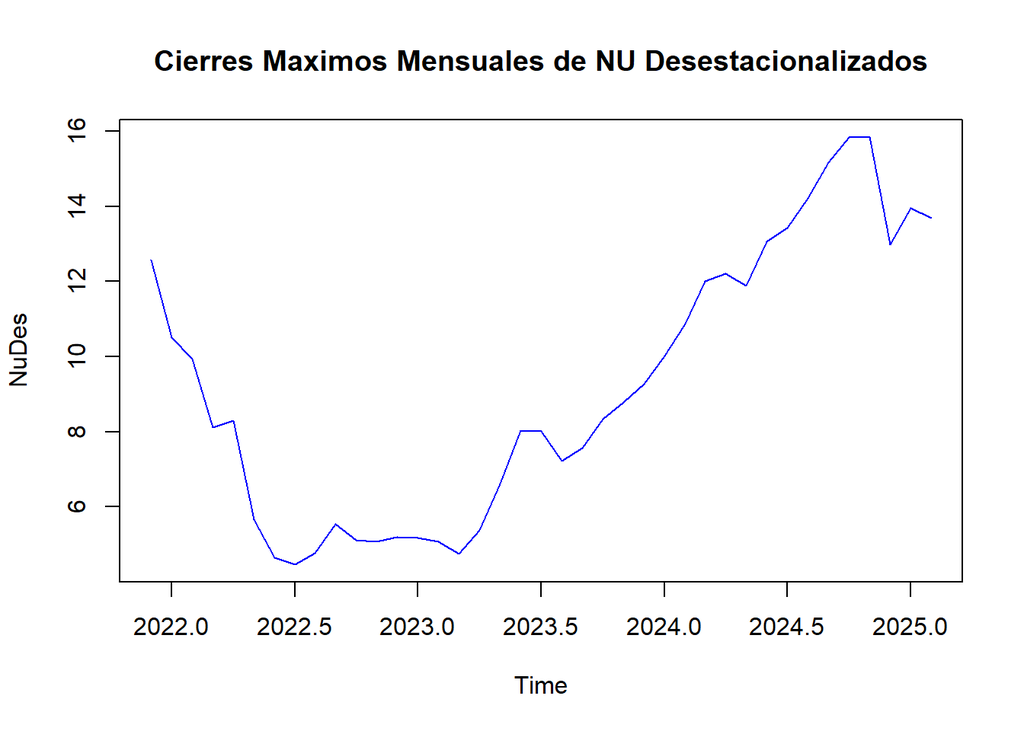

```r
plot(NuDes,main="Cierres Maximos Mensuales de NU Desestacionalizados",col="blue")
```

El grafico no cambio mucho después de extraer el componente estacionario

### Diferencias de la desestacionalización

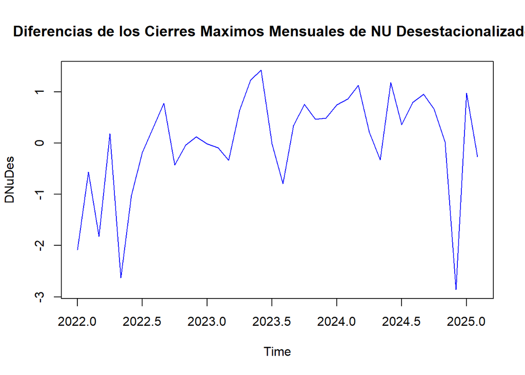

```r
plot(DNuDes,main="Diferencias de los Cierres Maximos Mensuales de NU Desestacionalizados",col="blue")
```

## ACF´s

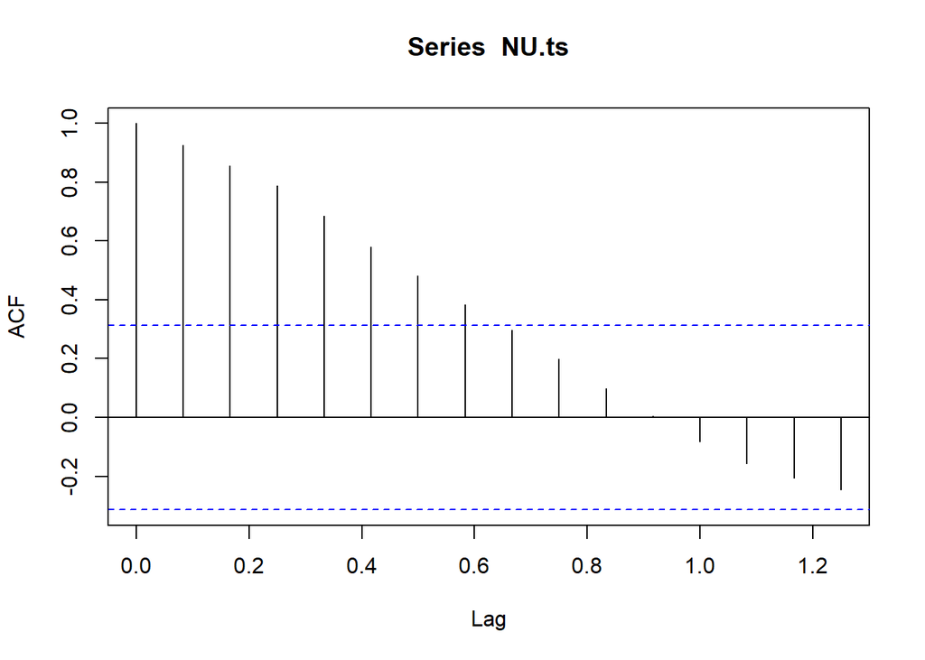

```r
acf(NU.ts)
```

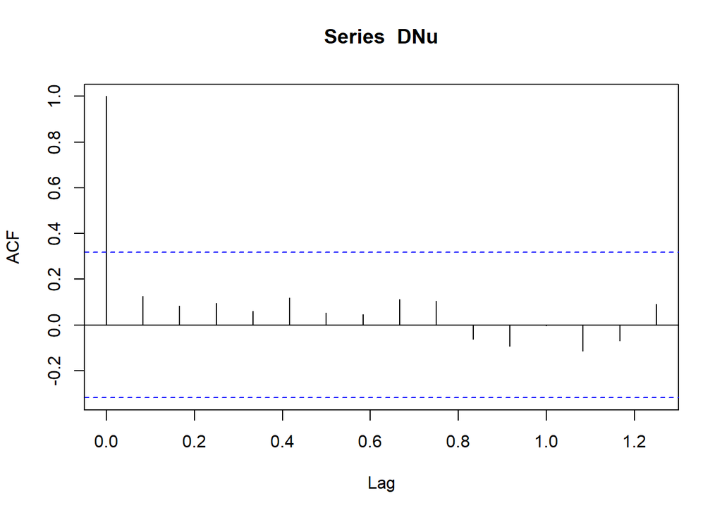

```r
acf(DNu)
```

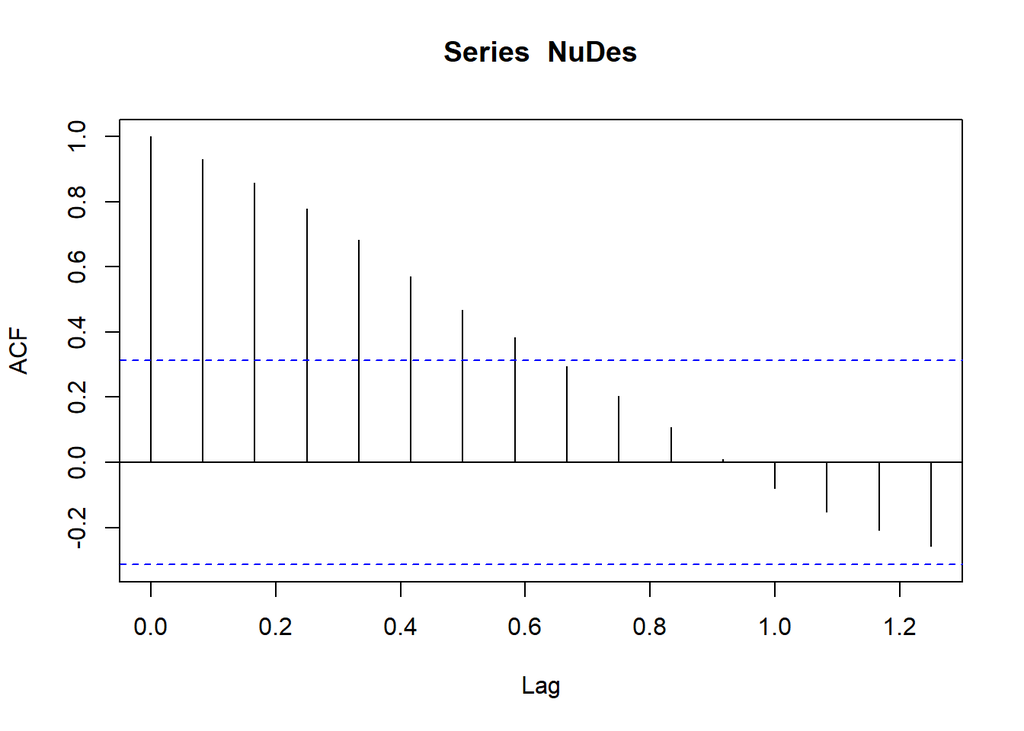

```r
acf(NuDes)
```

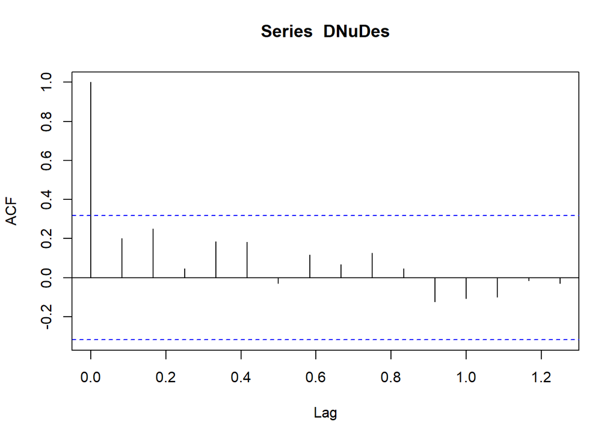

```r
acf(DNuDes)
```

## Dickey Fuller

```r
adf.test(NU.ts)
```

```
##
##  Augmented Dickey-Fuller Test
##
## data:  NU.ts
## Dickey-Fuller = -3.0364, Lag order = 3, p-value = 0.1675
## alternative hypothesis: stationary
```

```r
adf.test(DNu)
```

```
##
##  Augmented Dickey-Fuller Test
##
## data:  DNu
## Dickey-Fuller = -2.3433, Lag order = 3, p-value = 0.4391
## alternative hypothesis: stationary
```

```r
adf.test(NuDes)
```

```
##
##  Augmented Dickey-Fuller Test
##
## data:  NuDes
## Dickey-Fuller = -3.3848, Lag order = 3, p-value = 0.07405
## alternative hypothesis: stationary
```

```r
adf.test(DNuDes)
```

```
##
##  Augmented Dickey-Fuller Test
##
## data:  DNuDes
## Dickey-Fuller = -1.8399, Lag order = 3, p-value = 0.6359
## alternative hypothesis: stationary
```

Aparentemente ninguna es estacionaria

Hagamos una prueba

```r
adf.test(NU.ts,k=1)
```

```
##
##  Augmented Dickey-Fuller Test
##
## data:  NU.ts
## Dickey-Fuller = -2.7649, Lag order = 1, p-value = 0.2738
## alternative hypothesis: stationary
```

```r
adf.test(DNu,k=1)
```

```
##
##  Augmented Dickey-Fuller Test
##
## data:  DNu
## Dickey-Fuller = -3.8232, Lag order = 1, p-value = 0.0292
## alternative hypothesis: stationary
```

```r
adf.test(NuDes,k=1)
```

```
##
##  Augmented Dickey-Fuller Test
##
## data:  NuDes
## Dickey-Fuller = -3.1611, Lag order = 1, p-value = 0.1187
## alternative hypothesis: stationary
```

```r
adf.test(DNuDes,k=1)
```

```
##
##  Augmented Dickey-Fuller Test
##
## data:  DNuDes
## Dickey-Fuller = -3.2201, Lag order = 1, p-value = 0.09869
## alternative hypothesis: stationary
```

La diferencia de la variable original es estacionaria

## Modelos

Revisaremos todos los modelos conocidos pero nos aseguraremos al final de que la variable utilizada sea estacionaria

```r
#autoarima asumiendo que no hay ciclo
m1<- auto.arima(NU.ts, seasonal= FALSE)# Asumo que no hay ciclo
m2<- auto.arima(DNu, seasonal= FALSE)
m3<- auto.arima(NuDes,seasonal= FALSE)
m4<- auto.arima(DNuDes, seasonal= FALSE)


## Stepwise y aproximation false
m5<-auto.arima(NU.ts,seasonal = FALSE,
                 stepwise = FALSE,approximation = FALSE)
m6<-auto.arima(DNu,seasonal = FALSE,
                 stepwise = FALSE,approximation = FALSE)
m7<-auto.arima(NuDes,seasonal = FALSE,
                 stepwise = FALSE,approximation = FALSE)
m8<-auto.arima(DNuDes,seasonal = FALSE,
                 stepwise = FALSE,approximation = FALSE)

#autoarima asumiendo que hay ciclo
m9<- auto.arima(NU.ts, seasonal= TRUE)# Asumo que no hay ciclo
m10<- auto.arima(DNu, seasonal= TRUE)
m11<- auto.arima(NuDes,seasonal= TRUE)
m12<- auto.arima(DNuDes, seasonal= TRUE)

## Stepwise y aproximation false
m13<-auto.arima(NU.ts,seasonal = TRUE,
                 stepwise = FALSE,approximation = FALSE)
m14<-auto.arima(DNu,seasonal = TRUE,
                 stepwise = FALSE,approximation = FALSE)
m15<-auto.arima(NuDes,seasonal = TRUE,
                 stepwise = FALSE,approximation = FALSE)
m16<-auto.arima(DNuDes,seasonal = TRUE,
                 stepwise = FALSE,approximation = FALSE)
#Con tendencia
trend<-seq_along(NU.ts)
m17<-auto.arima(NU.ts,d=1,xreg=trend)
m18<-auto.arima(NU.ts,d=0,xreg=trend)
```

## Comparación de Criterios de Información

```r
AIC_BIC <- data.frame(
  Modelo = c("m1", "m2", "m3","m4","m5","m6","m7","m8","m9","m10","m11", "m12", "m13","m14","m15","m16","m17","m18"),
  AIC = c(m1$aic,m2$aic,m3$aic,m4$aic,m5$aic,m6$aic,m7$aic,m8$aic,m9$aic,m10$aic,m11$aic,m12$aic,m13$aic,m14$aic,m15$aic,m16$aic,m17$aic,m18$aic),
  BIC = c(m1$bic,m2$bic,m3$bic,m4$bic,m5$bic,m6$bic,m7$bic,m8$bic,m9$bic,m10$bic,m11$bic,m12$bic,m13$bic,m14$bic,m15$bic,m16$bic,m17$bic,m18$bic)
)

# Mostrar la tabla
knitr::kable(AIC_BIC, caption = "Comparación de AIC y BIC de los modelos auto.arima")
```

Comparación de AIC y BIC de los modelos auto.arima

| Modelo | AIC | BIC |
| --- | --- | --- |
| m1 | 115.6723 | 118.8941 |
| m2 | 115.6724 | 118.8942 |
| m3 | 107.0384 | 110.2603 |
| m4 | 107.0385 | 110.2603 |
| m5 | 115.6723 | 118.8941 |
| m6 | 115.6724 | 118.8942 |
| m7 | 107.0384 | 110.2603 |
| m8 | 107.0385 | 110.2603 |
| m9 | 115.6723 | 118.8941 |
| m10 | 115.6724 | 118.8942 |
| m11 | 107.0384 | 110.2603 |
| m12 | 107.0385 | 110.2603 |
| m13 | 115.6723 | 118.8941 |
| m14 | 115.6724 | 118.8942 |
| m15 | 107.0384 | 110.2603 |
| m16 | 107.0385 | 110.2603 |
| m17 | 117.3808 | 120.6560 |
| m18 | 125.0806 | 131.7349 |

## Mejor modelo

comprobemos sin son el mismo modelo

```r
m3
```

```
## Series: NuDes
## ARIMA(0,2,1)
##
## Coefficients:
##           ma1
##       -0.7545
## s.e.   0.1065
##
## sigma^2 = 0.9527:  log likelihood = -51.52
## AIC=107.04   AICc=107.39   BIC=110.26
```

```r
m4
```

```
## Series: DNuDes
## ARIMA(0,1,1)
##
## Coefficients:
##           ma1
##       -0.7545
## s.e.   0.1065
##
## sigma^2 = 0.9527:  log likelihood = -51.52
## AIC=107.04   AICc=107.39   BIC=110.26
```

```r
m7
```

```
## Series: NuDes
## ARIMA(0,2,1)
##
## Coefficients:
##           ma1
##       -0.7545
## s.e.   0.1065
##
## sigma^2 = 0.9527:  log likelihood = -51.52
## AIC=107.04   AICc=107.39   BIC=110.26
```

```r
m8
```

```
## Series: DNuDes
## ARIMA(0,1,1)
##
## Coefficients:
##           ma1
##       -0.7545
## s.e.   0.1065
##
## sigma^2 = 0.9527:  log likelihood = -51.52
## AIC=107.04   AICc=107.39   BIC=110.26
```

```r
m11
```

```
## Series: NuDes
## ARIMA(0,2,1)
##
## Coefficients:
##           ma1
##       -0.7545
## s.e.   0.1065
##
## sigma^2 = 0.9527:  log likelihood = -51.52
## AIC=107.04   AICc=107.39   BIC=110.26
```

```r
m12
```

```
## Series: DNuDes
## ARIMA(0,1,1)
##
## Coefficients:
##           ma1
##       -0.7545
## s.e.   0.1065
##
## sigma^2 = 0.9527:  log likelihood = -51.52
## AIC=107.04   AICc=107.39   BIC=110.26
```

```r
m15
```

```
## Series: NuDes
## ARIMA(0,2,1)
##
## Coefficients:
##           ma1
##       -0.7545
## s.e.   0.1065
##
## sigma^2 = 0.9527:  log likelihood = -51.52
## AIC=107.04   AICc=107.39   BIC=110.26
```

```r
m16
```

```
## Series: DNuDes
## ARIMA(0,1,1)
##
## Coefficients:
##           ma1
##       -0.7545
## s.e.   0.1065
##
## sigma^2 = 0.9527:  log likelihood = -51.52
## AIC=107.04   AICc=107.39   BIC=110.26
```

Efectivamente son el mismo modelo la variable desestacionalizada con dos diferencias y un rezago del error ARIMA(0,2,1)

Confirmemos que es estacionaria

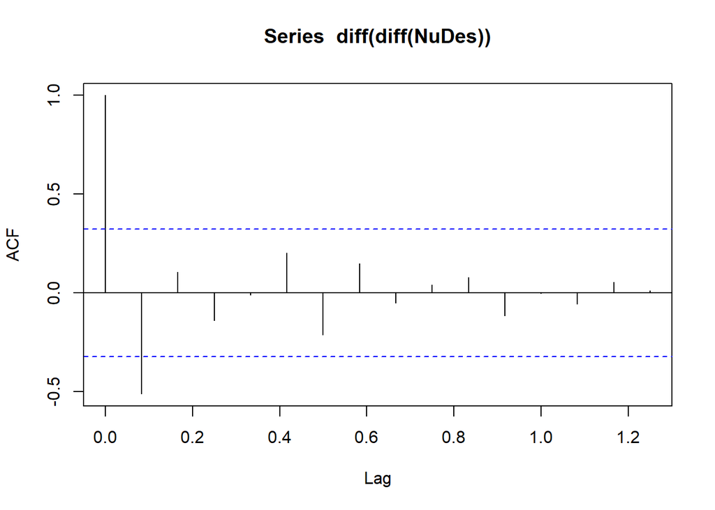

```r
acf(diff(diff(NuDes)))
```

```r
adf.test(diff(diff(NuDes)))
```

```
##
##  Augmented Dickey-Fuller Test
##
## data:  diff(diff(NuDes))
## Dickey-Fuller = -6.0886, Lag order = 3, p-value = 0.01
## alternative hypothesis: stationary
```

Es estacionaria pero el acf sugiere un rezago, probemos si es un mejor modelo

```r
macf2<-Arima(NuDes,order = c(1,2,1))
macf2
```

```
## Series: NuDes
## ARIMA(1,2,1)
##
## Coefficients:
##           ar1      ma1
##       -0.0737  -0.7259
## s.e.   0.2046   0.1400
##
## sigma^2 = 0.9762:  log likelihood = -51.46
## AIC=108.91   AICc=109.64   BIC=113.74
```

No es un mejor modelo por que los criterios AIC y BIC son más grandes

## Predicciones

```r
forecast(m3,h=3)
```

```
##          Point Forecast    Lo 80    Hi 80     Lo 95    Hi 95
## Mar 2025       13.62352 12.37261 14.87442 11.710420 15.53661
## Apr 2025       13.55637 11.55833 15.55441 10.500631 16.61211
## May 2025       13.48922 10.75594 16.22250  9.309032 17.66941
```

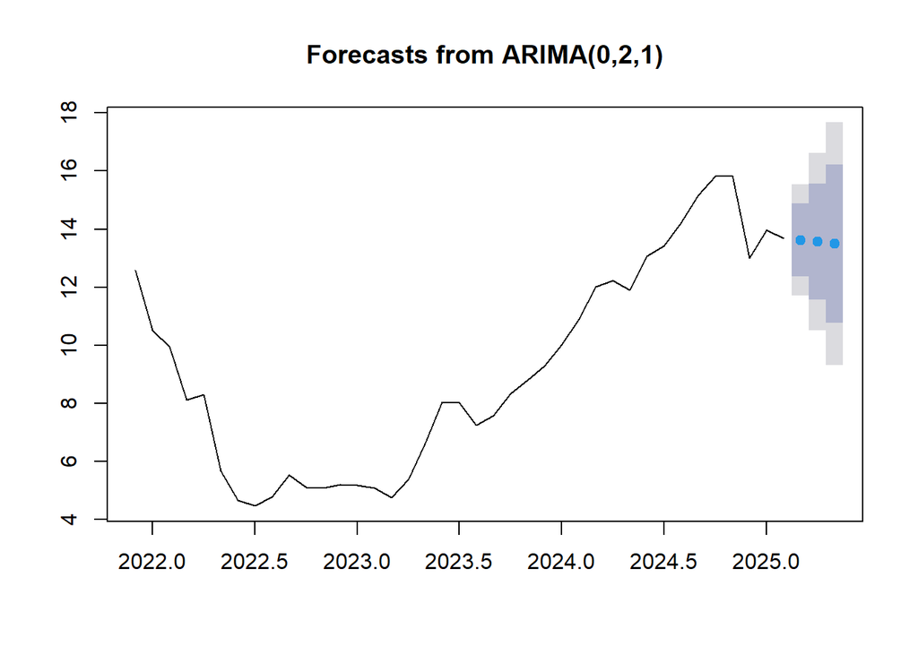

```r
plot(forecast(m3,h=3))
```

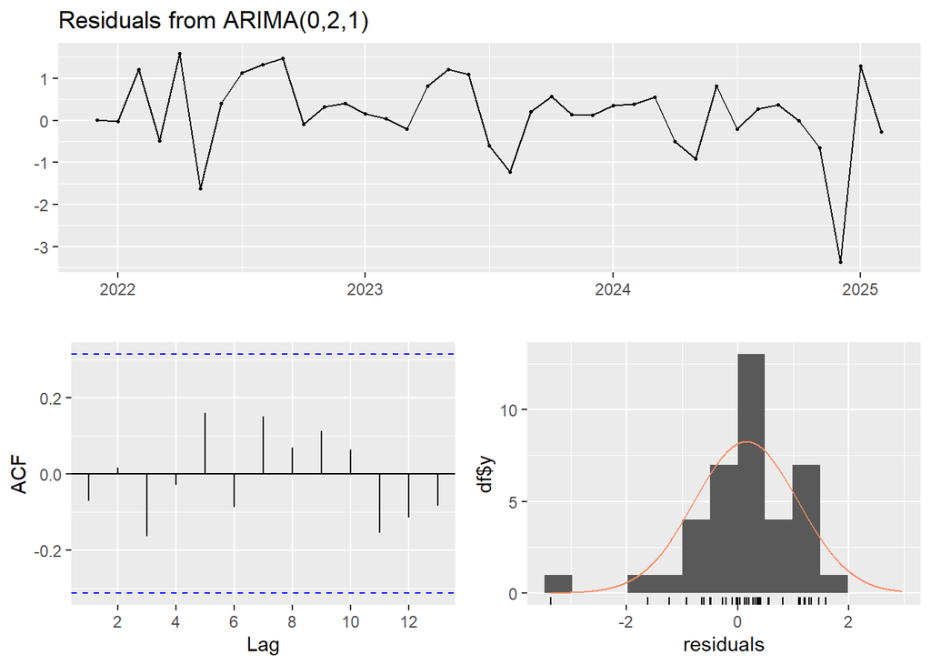

```
##
##  Ljung-Box test
##
## data:  Residuals from ARIMA(0,2,1)
## Q* = 4.4187, df = 7, p-value = 0.7305
##
## Model df: 1.   Total lags used: 8
```

```r
checkresiduals(m3)
```

# Conclusiones

El proceso de modelado implicó la aplicación de modelos ARIMA (5,2,0) y ARIMA (0,2,1) a dos series temporales distintas: el tipo de cambio USD/MXN y el precio de cierre máximo mensual de las acciones de Nu Holdings Ltd. (NU), respectivamente. A pesar de que se realizaron transformaciones para asegurar la estacionariedad de las series y se seleccionaron los modelos con base en criterios de información (AIC y BIC), el análisis de los residuos reveló limitaciones en la capacidad de los modelos para capturar completamente los patrones de los datos.  
En el caso del tipo de cambio USD/MXN, la presencia de autocorrelación en los residuos y la no normalidad de estos sugieren que el modelo ARIMA (5,2,0) no es adecuado para esta serie temporal. Para el precio de cierre máximo mensual de las acciones de NU, aunque el modelo ARIMA (0,2,1) no presenta autocorrelación en los residuos, se considera que exista heterocedasticidad, lo que indica que la varianza de los errores no es constante a lo largo del tiempo.  
Estos hallazgos tienen implicaciones importantes para la predicción de estas variables. En el caso del tipo de cambio USD/MXN, la autocorrelación y la no normalidad de los residuos invalidan la confiabilidad de las predicciones del modelo. Para el precio de cierre máximo mensual de las acciones de NU, la heterocedasticidad podría afectar la precisión de las predicciones del modelo.  
Se recomienda que futuros trabajos exploren modelos alternativos que puedan abordar las limitaciones observadas en los modelos ARIMA. En el caso del tipo de cambio USD/MXN, se sugiere la aplicación de modelos que no requieran la estacionariedad de la serie, como los modelos GARCH, que son capaces de modelar la volatilidad cambiante en el tiempo. Para el precio de cierre máximo mensual de las acciones de NU, se podrían considerar modelos que tengan en cuenta la heterocedasticidad, como los modelos ARCH o GARCH.  
Este estudio destaca la importancia de la selección adecuada del modelo y el análisis de los residuos para asegurar la validez y confiabilidad de las predicciones. La aplicación de modelos ARIMA a las series temporales del tipo de cambio USD/MXN y el precio de cierre máximo mensual de las acciones de NU reveló limitaciones en la capacidad de estos modelos para capturar completamente los patrones de los datos, lo que sugiere la necesidad de explorar modelos alternativos en futuros trabajos.

# Referencias

- Hill, R. C., Griffiths, W. E., & Lim, G. C. (2017). Principles of Econometrics (5th ed.). Wiley.
- Banco de México. (s.f.). Portal del mercado cambiario. Recuperado de https://www.banxico.org.mx/
- Yahoo Finanzas. (s.f.). Nu Holdings Ltd. (NU). Recuperado de https://es.finance.yahoo.com/quote/NU/